# Google Maps Location data

Harsha Achyuthuni

December 11, 2018

## Integrating Google location history

I want to integrate my Google Location history to my analysis. This to find the factors  
1. Traffic( Travel time / distance )  
2. Vehicle used

It’s no secret that Google stores a data on all of us. But at least they allow us to access quite a lot of the data they have collected on us. Among this is the Google location history.

The Google location history can be downloaded from your Google account under https://takeout.google.com/settings/takeout. Make sure you only tick “location history” for download, otherwise it will take super long to get all your Google data.

The data Google provides you for download is a .json file and can be loaded with the jsonlite package. Loading this file into R might take a few minutes because it can be quite big, depending on how many location points Google had saved about you.

```r
library(jsonlite)
setwd('C:/Users/achyuthuni.harsha/Desktop/Blog/takeout-20181205T104628Z-001/Takeout/Location History')
system.time(
  x <- fromJSON("Location History.json")
)
```

```
##    user  system elapsed
##   33.09    0.83   34.65
```

Converting to data frame

```r
locations <- as.data.frame(x$locations)
dplyr::sample_n(locations, 5)
```

```
##          timestampMs latitudeE7 longitudeE7 accuracy
## 103365 1536096790010  129768902   777331000       26
## 35910  1540915392804  129831967   777385539       25
## 122524 1533614092634  129768885   777331206       24
## 250121 1514781948632  129762573   777340167       30
## 172682 1526581945449  129768248   777331578       26
##                                                                                                                                                              activity
## 103365                                                                                                                                                           NULL
## 35910                                                                                                                                                            NULL
## 122524                                                                                                                                                           NULL
## 250121                                                                                                                                                           NULL
## 172682 1526581948974, STILL, IN_VEHICLE, IN_ROAD_VEHICLE, UNKNOWN, UNKNOWN, ON_FOOT, WALKING, IN_RAIL_VEHICLE, UNKNOWN, ON_BICYCLE, 61, 26, 26, 13, 13, 5, 5, 4, 3, 1
##        altitude verticalAccuracy velocity heading
## 103365       NA               NA       NA      NA
## 35910        NA               NA       NA      NA
## 122524       NA               NA       NA      NA
## 250121       NA               NA       NA      NA
## 172682       NA               NA       NA      NA
```

The date and time column is in the POSIX milliseconds format, so I converted it to human readable format.

```r
# The Unix epoch is 1970-01-01 00:00:00 UTC*
locations$time <- as.POSIXct(as.numeric(locations$timestampMs)/1000, origin = "1970-01-01")
```

Similarly, longitude and latitude are saved in 10^7 format and were converted to GPS coordinates.

```r
locations$lat = locations$latitudeE7 / 1e7
locations$lon = locations$longitudeE7 / 1e7
```

The modified dataFrame will look like this

```
##                       time      lat      lon accuracy
## 52943  2018-10-15 20:35:10 12.98313 77.73848       25
## 261208 2017-12-10 01:28:14 12.97703 77.73333       20
## 222407 2018-02-20 11:54:46 12.97704 77.73311       23
## 31771  2018-11-04 20:15:41 12.97459 77.75759       16
## 135606 2018-07-18 22:39:30 12.98714 77.73598       26
##                           activity
## 52943                         NULL
## 261208                        NULL
## 222407 1519107857104, TILTING, 100
## 31771    1541342741418, STILL, 100
## 135606                        NULL
```

### Data stats

Before I get to actually plotting maps, I want to explore a few basic statistics of the data.  
1. How many data points did Google record over what period of time?

```r
nrow(locations)
```

```
## [1] 268248
```

2. Fron when till when is this data recorded

```r
min(locations$time)
```

```
## [1] "2017-11-22 13:20:07 IST"
```

```r
max(locations$time)
```

```
## [1] "2018-12-05 15:14:54 IST"
```

3. How many days were recorded?

```r
length(unique(date(locations$time)))
```

```
## [1] 379
```

### Integrating with attendence data set

Finding how many working days are captured

```r
working_days <- locations %>%
  filter((date(time) %in% date(attendance$Attendance.Date)))
length(unique(date(working_days$time)))
```

```
## [1] 246
```

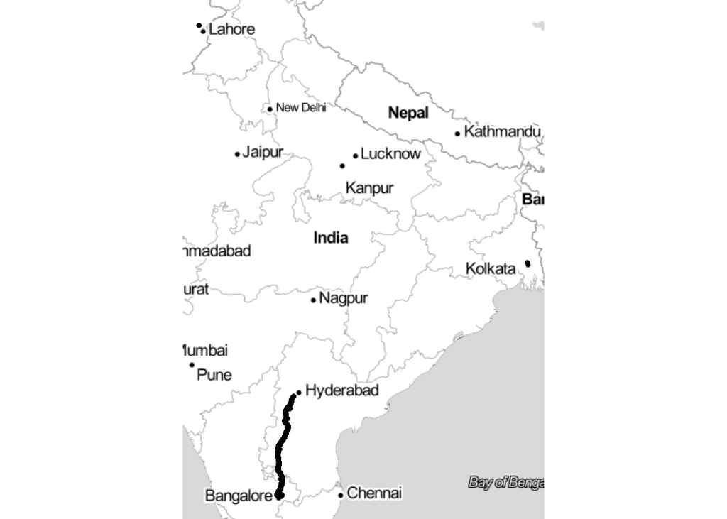

```r
library(ggmap)
qmplot(lon, lat, data = working_days, zoom = 5)
```